# Practical ML

Ralph Knag

Wednesday, December 17, 2014

Barbell Lift Detection Model

I wasn’t sure how to approach this problem. At first I thought about just doing a linear regression, but after looking at the data I realized there were a fair number of predictors. I thought I should try to reduce them if using a linear model (perhaps by using PCA). Then I read the Wearable Computing document by Wallace Ugulino, Débora Cardador, Katia Vega, Eduardo Velloso, Ruy Milidiú and Hugo Fuks and noticed that they had used random forests. I decided to try this method out for the first time.

```r
# read in the tranining (really used for both training and initial testing). Convert divide by zero to NA
training <- read.csv("C:/TEMP/pml-training.csv", header=TRUE,sep=",",na.strings=c("NA", "#DIV/0!"))
# the first seven variables are not useful (timestamps and state information)
ctraining <- training[,8:160]
require(caret)
# get rid of mostly NA variables
ctrainingfilterna <- ctraining[,colSums(is.na(ctraining)) <  1000]
# get rid of remaining rows with NA
ctrainingnona <- ctrainingfilterna[complete.cases(ctrainingfilterna),]
# split into test and train
set.seed(1356)
dp <- createDataPartition(ctrainingnona$classe, p=.6, list=FALSE)
train <- ctrainingnona[dp,]
test <- ctrainingnona[-dp,]
```

Then I used caret’s train to run a cross validation. I used the oob method at first and it ran much faster, but I guess it’s not quite a “cross validation” technique, although it appears to be similar. I finally tried cross validation with 5 folds to tune the model’s variables. I look at the model to see what was selected. I also examined the importance of the variables using importance. I plot the model to see the number of trees used. I also run rfcv to look for overfitting because of too many variables.

```r
rf <- train(ctrainingnona[,1:length(ctrainingnona)-1], ctrainingnona$classe, method = "rf",   trControl = trainControl(method = "cv", number=5), importance = TRUE, verbose = TRUE, na.action="omit")
rf
```

```
## Random Forest
##
## 19622 samples
##    52 predictor
##     5 classes: 'A', 'B', 'C', 'D', 'E'
##
## No pre-processing
## Resampling: Cross-Validated (5 fold)
##
## Summary of sample sizes: 15698, 15698, 15696, 15699, 15697
##
## Resampling results across tuning parameters:
##
##   mtry  Accuracy  Kappa  Accuracy SD  Kappa SD
##    2    1         1      9e-04        1e-03
##   27    1         1      6e-04        7e-04
##   52    1         1      3e-03        4e-03
##
## Accuracy was used to select the optimal model using  the largest value.
## The final value used for the model was mtry = 2.
```

```r
df <- data.frame(importance(rf$finalModel))
df[order(df$MeanDecreaseGini,decreasing=TRUE),]
```

```
##                          A     B     C     D     E MeanDecreaseAccuracy
## roll_belt            31.44 38.74 38.67 35.70 29.64                40.81
## yaw_belt             36.59 38.55 32.63 38.02 28.63                45.72
## magnet_dumbbell_z    31.53 30.92 35.32 30.54 30.11                36.06
## pitch_belt           32.12 37.57 32.12 32.01 32.06                40.88
## magnet_dumbbell_y    26.51 28.77 34.79 27.93 25.90                32.37
## pitch_forearm        24.72 28.74 26.82 27.77 27.28                31.81
## magnet_dumbbell_x    23.55 24.45 29.64 23.42 20.80                26.37
## roll_forearm         22.56 23.64 26.69 24.13 23.14                25.66
## magnet_belt_z        26.06 28.23 27.91 28.92 27.22                32.14
## accel_dumbbell_y     25.96 30.57 28.58 30.65 28.76                34.01
## magnet_belt_y        22.36 27.73 27.06 28.63 24.21                30.20
## accel_belt_z         24.27 29.90 28.12 26.91 24.83                32.93
## roll_dumbbell        23.20 24.08 27.04 26.40 23.62                27.76
## roll_arm             23.91 35.76 31.59 30.10 27.95                36.18
## accel_dumbbell_z     24.94 29.23 28.65 27.36 28.57                33.22
## accel_forearm_x      20.01 24.49 25.81 24.97 22.65                25.40
## yaw_dumbbell         19.28 22.89 24.75 22.81 23.34                24.21
## accel_dumbbell_x     20.81 26.21 27.05 23.78 25.53                28.82
## gyros_belt_z         24.16 28.83 27.94 26.73 27.96                32.30
## magnet_arm_x         19.96 20.61 22.93 21.30 18.10                22.33
## magnet_forearm_z     22.39 26.20 25.37 27.04 24.48                28.14
## total_accel_dumbbell 23.87 24.74 22.48 24.51 24.16                27.09
## gyros_dumbbell_y     23.06 26.61 27.08 23.97 23.11                27.17
## accel_arm_x          19.76 23.03 21.95 25.59 19.70                24.15
## magnet_arm_y         18.40 21.26 21.70 22.30 19.18                22.00
## magnet_forearm_x     18.69 21.46 22.53 23.00 19.95                22.91
## magnet_forearm_y     22.45 23.60 26.01 24.33 22.60                26.29
## magnet_belt_x        21.97 27.74 27.84 23.46 29.18                30.82
## accel_forearm_z      23.12 29.13 28.80 26.12 26.43                32.55
## total_accel_belt     18.48 24.09 19.99 19.68 21.48                23.97
## yaw_arm              22.25 30.15 26.75 29.18 27.03                31.55
## pitch_dumbbell       15.50 21.26 21.62 18.62 18.08                20.02
## magnet_arm_z         23.07 25.19 27.36 25.20 21.87                27.65
## pitch_arm            17.91 23.89 21.59 21.14 17.71                21.87
## yaw_forearm          22.43 26.08 27.71 25.33 26.08                31.87
## accel_arm_y          20.68 28.13 24.41 25.40 23.80                28.78
## accel_forearm_y      22.54 26.45 25.96 24.42 22.52                28.48
## gyros_arm_x          19.39 25.21 24.51 23.39 20.95                25.06
## gyros_arm_y          20.49 27.85 23.65 25.87 21.80                27.01
```

[output cut: 51 more lines]

```
## gyros_arm_x                     210.7
## gyros_arm_y                     205.1
## accel_arm_z                     204.6
## accel_belt_x                    195.6
## gyros_forearm_y                 191.0
## gyros_dumbbell_x                189.5
## accel_belt_y                    180.8
## total_accel_forearm             176.7
## total_accel_arm                 172.7
## gyros_belt_y                    172.4
## gyros_belt_x                    168.4
## gyros_dumbbell_z                146.1
## gyros_forearm_z                 143.0
## gyros_forearm_x                 142.4
## gyros_arm_z                     122.1
```

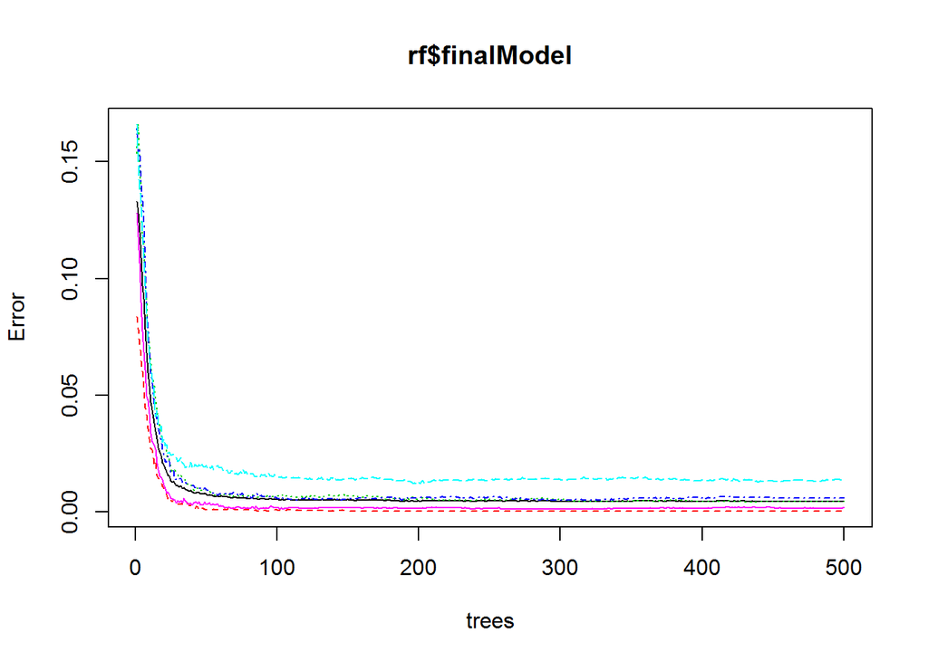

```r
plot(rf$finalModel)
```

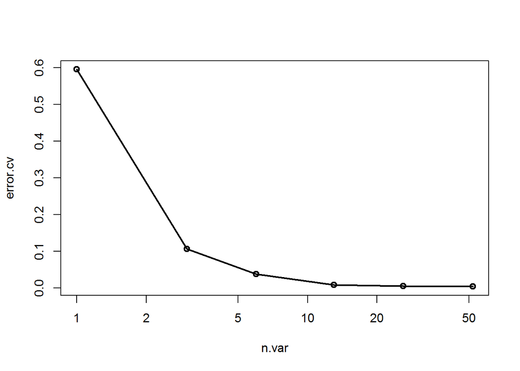

```r
# look at rfcv to use cross validation to check for overfitting
trfcv <- rfcv(ctrainingnona[,1:length(ctrainingnona)-1], ctrainingnona$classe,cv.fold=5)
#looks like there fewer variables are possible if we overfit.
with(trfcv, plot(n.var, error.cv, log="x", type="o", lwd=2))
```

```r
pred <- predict(rf$finalModel, test)
confusionMatrix(pred, test$classe)
```

```
## Confusion Matrix and Statistics
##
##           Reference
## Prediction    A    B    C    D    E
##          A 2232    0    0    0    0
##          B    0 1518    0    0    0
##          C    0    0 1368    0    0
##          D    0    0    0 1286    0
##          E    0    0    0    0 1442
##
## Overall Statistics
##
##                Accuracy : 1
##                  95% CI : (1, 1)
##     No Information Rate : 0.284
##     P-Value [Acc > NIR] : <2e-16
##
##                   Kappa : 1
##  Mcnemar's Test P-Value : NA
##
## Statistics by Class:
##
##                      Class: A Class: B Class: C Class: D Class: E
## Sensitivity             1.000    1.000    1.000    1.000    1.000
## Specificity             1.000    1.000    1.000    1.000    1.000
## Pos Pred Value          1.000    1.000    1.000    1.000    1.000
## Neg Pred Value          1.000    1.000    1.000    1.000    1.000
## Prevalence              0.284    0.193    0.174    0.164    0.184
## Detection Rate          0.284    0.193    0.174    0.164    0.184
## Detection Prevalence    0.284    0.193    0.174    0.164    0.184
## Balanced Accuracy       1.000    1.000    1.000    1.000    1.000
```

Finally I read in the final test cases for submission, do the prediction and write out the results.

```r
testing <- read.csv("C:/TEMP/pml-testing.csv", header=TRUE,sep=",",na.strings=c("NA", "#DIV/0!"))
# the first seven variables are not useful (timestamps and state information)
ctesting <- testing[,8:159]
# get rid of mostly NA variables
ctestingfilterna <- ctesting[,colSums(is.na(ctesting)) == 0]
# get rid of remaining rows with NA
ctestingnona <- ctestingfilterna[complete.cases(ctestingfilterna),]
ptest <-  predict(rf$finalModel, ctestingnona)
ptest
```

```
##  1  2  3  4  5  6  7  8  9 10 11 12 13 14 15 16 17 18 19 20
##  B  A  B  A  A  E  D  B  A  A  B  C  B  A  E  E  A  B  B  B
## Levels: A B C D E
```

```r
pml_write_files = function(x){
  n = length(x)
  for(i in 1:n){
    filename = paste0("problem_id_",i,".txt")
    write.table(x[i],file=filename,quote=FALSE,row.names=FALSE,col.names=FALSE)
  }
}
pml_write_files(ptest)
```